# John Hopkins Covid-19 Data Project

DM

2024-10-12

## Load Data

The data comes from John Hopkins from the COVID-19 pandemic and was archived on Mar 10, 2023.

```r
library(tidyverse)
library(lubridate)
url_in <- "https://raw.githubusercontent.com/CSSEGISandData/COVID-19/master/csse_covid_19_data/csse_covid_19_time_series/"

file_names <-c("time_series_covid19_confirmed_global.csv",
               "time_series_covid19_deaths_global.csv",
               "time_series_covid19_confirmed_US.csv",
               "time_series_covid19_deaths_US.csv")

urls <- str_c(url_in, file_names)
urls
```

```
## [1] "https://raw.githubusercontent.com/CSSEGISandData/COVID-19/master/csse_covid_19_data/csse_covid_19_time_series/time_series_covid19_confirmed_global.csv"
## [2] "https://raw.githubusercontent.com/CSSEGISandData/COVID-19/master/csse_covid_19_data/csse_covid_19_time_series/time_series_covid19_deaths_global.csv"
## [3] "https://raw.githubusercontent.com/CSSEGISandData/COVID-19/master/csse_covid_19_data/csse_covid_19_time_series/time_series_covid19_confirmed_US.csv"
## [4] "https://raw.githubusercontent.com/CSSEGISandData/COVID-19/master/csse_covid_19_data/csse_covid_19_time_series/time_series_covid19_deaths_US.csv"
```

```r
global_cases <- read_csv(urls[1])
global_deaths <- read_csv(urls[2])
US_cases <- read_csv(urls[3])
US_deaths <- read_csv(urls[4])
```

## Cleaning and Transforming Data

```r
#tidy data

global_cases <- global_cases %>%
  pivot_longer(cols = -c('Province/State','Country/Region', Lat, Long),
               names_to = "date",
               values_to = "cases") %>%
  select(-c(Lat,Long))

head(global_cases, n=10)
```

| Province/State | Country/Region | date | cases |
| --- | --- | --- | --- |
| NA | Afghanistan | 1/22/20 | 0 |
| NA | Afghanistan | 1/23/20 | 0 |
| NA | Afghanistan | 1/24/20 | 0 |
| NA | Afghanistan | 1/25/20 | 0 |
| NA | Afghanistan | 1/26/20 | 0 |
| NA | Afghanistan | 1/27/20 | 0 |
| NA | Afghanistan | 1/28/20 | 0 |
| NA | Afghanistan | 1/29/20 | 0 |
| NA | Afghanistan | 1/30/20 | 0 |
| NA | Afghanistan | 1/31/20 | 0 |

```r
global_deaths <- global_deaths %>%
  pivot_longer(cols = -c('Province/State','Country/Region', Lat, Long),
               names_to = "date",
               values_to = "deaths") %>%
  select(-c(Lat,Long))

head(global_deaths, n=10)
```

| Province/State | Country/Region | date | deaths |
| --- | --- | --- | --- |
| NA | Afghanistan | 1/22/20 | 0 |
| NA | Afghanistan | 1/23/20 | 0 |
| NA | Afghanistan | 1/24/20 | 0 |
| NA | Afghanistan | 1/25/20 | 0 |
| NA | Afghanistan | 1/26/20 | 0 |
| NA | Afghanistan | 1/27/20 | 0 |
| NA | Afghanistan | 1/28/20 | 0 |
| NA | Afghanistan | 1/29/20 | 0 |
| NA | Afghanistan | 1/30/20 | 0 |
| NA | Afghanistan | 1/31/20 | 0 |

```r
#transform data
#combine the cases into deaths per date into one variable called global
global <- global_cases %>%
  full_join(global_deaths) %>%
  rename(`Country_Region`='Country/Region',
         Province_State = 'Province/State') %>%
  mutate(date = mdy(date))
global <- global %>% filter(cases >0)
summary(global)
```

```
##  Province_State     Country_Region          date                cases
##  Length:306827      Length:306827      Min.   :2020-01-22   Min.   :        1
##  Class :character   Class :character   1st Qu.:2020-12-12   1st Qu.:     1316
##  Mode  :character   Mode  :character   Median :2021-09-16   Median :    20365
##                                        Mean   :2021-09-11   Mean   :  1032863
##                                        3rd Qu.:2022-06-15   3rd Qu.:   271281
##                                        Max.   :2023-03-09   Max.   :103802702
##      deaths
##  Min.   :      0
##  1st Qu.:      7
##  Median :    214
##  Mean   :  14405
##  3rd Qu.:   3665
##  Max.   :1123836
```

```r
#double check amount of cases close to maximum
global %>% filter(cases > 103000000)
```

| Province_State | Country_Region | date | cases | deaths |
| --- | --- | --- | --- | --- |
| NA | US | 2023-02-15 | 103023231 | 1115741 |
| NA | US | 2023-02-16 | 103083910 | 1116851 |
| NA | US | 2023-02-17 | 103131898 | 1117572 |
| NA | US | 2023-02-18 | 103134605 | 1117589 |
| NA | US | 2023-02-19 | 103136077 | 1117590 |
| NA | US | 2023-02-20 | 103138119 | 1117663 |
| NA | US | 2023-02-21 | 103198669 | 1118025 |
| NA | US | 2023-02-22 | 103308832 | 1118886 |
| NA | US | 2023-02-23 | 103365511 | 1119521 |
| NA | US | 2023-02-24 | 103378408 | 1119573 |

[output cut: 13 more lines]

```r
#now clean and wrangle US cases
US_cases %>%
  pivot_longer(cols = -(UID:Combined_Key),
               names_to = "date",
               values_to = "cases")
```

| UID | iso2 | iso3 | code3 | FIPS | Admin2 | Province_State | Country_Region | Lat | Long_ | Combined_Key | date | cases |
| --- | --- | --- | --- | --- | --- | --- | --- | --- | --- | --- | --- | --- |
| 84001001 | US | USA | 840 | 1001 | Autauga | Alabama | US | 32.53953 | -86.64408 | Autauga, Alabama, US | 1/22/20 | 0 |
| 84001001 | US | USA | 840 | 1001 | Autauga | Alabama | US | 32.53953 | -86.64408 | Autauga, Alabama, US | 1/23/20 | 0 |
| 84001001 | US | USA | 840 | 1001 | Autauga | Alabama | US | 32.53953 | -86.64408 | Autauga, Alabama, US | 1/24/20 | 0 |
| 84001001 | US | USA | 840 | 1001 | Autauga | Alabama | US | 32.53953 | -86.64408 | Autauga, Alabama, US | 1/25/20 | 0 |
| 84001001 | US | USA | 840 | 1001 | Autauga | Alabama | US | 32.53953 | -86.64408 | Autauga, Alabama, US | 1/26/20 | 0 |
| 84001001 | US | USA | 840 | 1001 | Autauga | Alabama | US | 32.53953 | -86.64408 | Autauga, Alabama, US | 1/27/20 | 0 |
| 84001001 | US | USA | 840 | 1001 | Autauga | Alabama | US | 32.53953 | -86.64408 | Autauga, Alabama, US | 1/28/20 | 0 |
| 84001001 | US | USA | 840 | 1001 | Autauga | Alabama | US | 32.53953 | -86.64408 | Autauga, Alabama, US | 1/29/20 | 0 |
| 84001001 | US | USA | 840 | 1001 | Autauga | Alabama | US | 32.53953 | -86.64408 | Autauga, Alabama, US | 1/30/20 | 0 |
| 84001001 | US | USA | 840 | 1001 | Autauga | Alabama | US | 32.53953 | -86.64408 | Autauga, Alabama, US | 1/31/20 | 0 |

[output cut: 9990 more lines]

```r
US_cases <- US_cases %>%
  pivot_longer(cols = -(UID:Combined_Key),
                names_to = "date",
                values_to = "cases") %>%
  select(Admin2:cases) %>%
  mutate(date=mdy(date)) %>%
  select(-c(Lat,Long_))

head(US_cases, n=10)
```

| Admin2 | Province_State | Country_Region | Combined_Key | date | cases |
| --- | --- | --- | --- | --- | --- |
| Autauga | Alabama | US | Autauga, Alabama, US | 2020-01-22 | 0 |
| Autauga | Alabama | US | Autauga, Alabama, US | 2020-01-23 | 0 |
| Autauga | Alabama | US | Autauga, Alabama, US | 2020-01-24 | 0 |
| Autauga | Alabama | US | Autauga, Alabama, US | 2020-01-25 | 0 |
| Autauga | Alabama | US | Autauga, Alabama, US | 2020-01-26 | 0 |
| Autauga | Alabama | US | Autauga, Alabama, US | 2020-01-27 | 0 |
| Autauga | Alabama | US | Autauga, Alabama, US | 2020-01-28 | 0 |
| Autauga | Alabama | US | Autauga, Alabama, US | 2020-01-29 | 0 |
| Autauga | Alabama | US | Autauga, Alabama, US | 2020-01-30 | 0 |
| Autauga | Alabama | US | Autauga, Alabama, US | 2020-01-31 | 0 |

```r
US_deaths <- US_deaths %>%
  pivot_longer(cols = -(UID:Population),
               names_to = "date",
               values_to = "deaths") %>%
  select(Admin2:deaths) %>%
  mutate(date=mdy(date)) %>%
  select(-c(Lat,Long_))

head(US_deaths, n=10)
```

| Admin2 | Province_State | Country_Region | Combined_Key | Population | date | deaths |
| --- | --- | --- | --- | --- | --- | --- |
| Autauga | Alabama | US | Autauga, Alabama, US | 55869 | 2020-01-22 | 0 |
| Autauga | Alabama | US | Autauga, Alabama, US | 55869 | 2020-01-23 | 0 |
| Autauga | Alabama | US | Autauga, Alabama, US | 55869 | 2020-01-24 | 0 |
| Autauga | Alabama | US | Autauga, Alabama, US | 55869 | 2020-01-25 | 0 |
| Autauga | Alabama | US | Autauga, Alabama, US | 55869 | 2020-01-26 | 0 |
| Autauga | Alabama | US | Autauga, Alabama, US | 55869 | 2020-01-27 | 0 |
| Autauga | Alabama | US | Autauga, Alabama, US | 55869 | 2020-01-28 | 0 |
| Autauga | Alabama | US | Autauga, Alabama, US | 55869 | 2020-01-29 | 0 |
| Autauga | Alabama | US | Autauga, Alabama, US | 55869 | 2020-01-30 | 0 |
| Autauga | Alabama | US | Autauga, Alabama, US | 55869 | 2020-01-31 | 0 |

```r
#join two US datasets together
US <- US_cases %>%
  full_join(US_deaths)
```

[output not shown]

```r
#check join
head(US, n=10)
```

| Admin2 | Province_State | Country_Region | Combined_Key | date | cases | Population | deaths |
| --- | --- | --- | --- | --- | --- | --- | --- |
| Autauga | Alabama | US | Autauga, Alabama, US | 2020-01-22 | 0 | 55869 | 0 |
| Autauga | Alabama | US | Autauga, Alabama, US | 2020-01-23 | 0 | 55869 | 0 |
| Autauga | Alabama | US | Autauga, Alabama, US | 2020-01-24 | 0 | 55869 | 0 |
| Autauga | Alabama | US | Autauga, Alabama, US | 2020-01-25 | 0 | 55869 | 0 |
| Autauga | Alabama | US | Autauga, Alabama, US | 2020-01-26 | 0 | 55869 | 0 |
| Autauga | Alabama | US | Autauga, Alabama, US | 2020-01-27 | 0 | 55869 | 0 |
| Autauga | Alabama | US | Autauga, Alabama, US | 2020-01-28 | 0 | 55869 | 0 |
| Autauga | Alabama | US | Autauga, Alabama, US | 2020-01-29 | 0 | 55869 | 0 |
| Autauga | Alabama | US | Autauga, Alabama, US | 2020-01-30 | 0 | 55869 | 0 |
| Autauga | Alabama | US | Autauga, Alabama, US | 2020-01-31 | 0 | 55869 | 0 |

```r
#add population data to global dataset

global <- global %>%
  unite("Combined_Key",
        c(Province_State, Country_Region),
        sep=", ",
        na.rm=TRUE,
        remove=FALSE)

head(global, n=10)
```

| Combined_Key | Province_State | Country_Region | date | cases | deaths |
| --- | --- | --- | --- | --- | --- |
| Afghanistan | NA | Afghanistan | 2020-02-24 | 5 | 0 |
| Afghanistan | NA | Afghanistan | 2020-02-25 | 5 | 0 |
| Afghanistan | NA | Afghanistan | 2020-02-26 | 5 | 0 |
| Afghanistan | NA | Afghanistan | 2020-02-27 | 5 | 0 |
| Afghanistan | NA | Afghanistan | 2020-02-28 | 5 | 0 |
| Afghanistan | NA | Afghanistan | 2020-02-29 | 5 | 0 |
| Afghanistan | NA | Afghanistan | 2020-03-01 | 5 | 0 |
| Afghanistan | NA | Afghanistan | 2020-03-02 | 5 | 0 |
| Afghanistan | NA | Afghanistan | 2020-03-03 | 5 | 0 |
| Afghanistan | NA | Afghanistan | 2020-03-04 | 5 | 0 |

```r
#retrieve lookup table URL from John Hopkins Website

uid_lookup_url <- "https://raw.githubusercontent.com/CSSEGISandData/COVID-19/master/csse_covid_19_data/UID_ISO_FIPS_LookUp_Table.csv"

uid <- read_csv(uid_lookup_url) %>%
  select(-c(Lat, Long_, Combined_Key, code3, iso2, iso3, Admin2))
#join uid onto global dataset

global <- global %>%
  left_join(uid, by=c("Province_State","Country_Region")) %>%
  select(-c(UID, FIPS)) %>%
  select(Province_State, Country_Region, date, cases, deaths, Population, Combined_Key)

head(global, n=10)
```

| Province_State | Country_Region | date | cases | deaths | Population | Combined_Key |
| --- | --- | --- | --- | --- | --- | --- |
| NA | Afghanistan | 2020-02-24 | 5 | 0 | 38928341 | Afghanistan |
| NA | Afghanistan | 2020-02-25 | 5 | 0 | 38928341 | Afghanistan |
| NA | Afghanistan | 2020-02-26 | 5 | 0 | 38928341 | Afghanistan |
| NA | Afghanistan | 2020-02-27 | 5 | 0 | 38928341 | Afghanistan |
| NA | Afghanistan | 2020-02-28 | 5 | 0 | 38928341 | Afghanistan |
| NA | Afghanistan | 2020-02-29 | 5 | 0 | 38928341 | Afghanistan |
| NA | Afghanistan | 2020-03-01 | 5 | 0 | 38928341 | Afghanistan |
| NA | Afghanistan | 2020-03-02 | 5 | 0 | 38928341 | Afghanistan |
| NA | Afghanistan | 2020-03-03 | 5 | 0 | 38928341 | Afghanistan |
| NA | Afghanistan | 2020-03-04 | 5 | 0 | 38928341 | Afghanistan |

In the data cleaning and transformation, we removed unnecessary columns for our analysis like latitude and longitude. We combined the cases into deaths per date into one variable called global. Combined_key puts together the county and the state for US cases.

## Visualizing Data

```r
#First, group US dataset by state, region, and date
US_by_state <- US %>%
  group_by(Province_State, Country_Region, date) %>%
  summarize(cases = sum(cases), deaths = sum(deaths),
            Population = sum(Population)) %>%
  mutate(deaths_per_mill = deaths * 1000000 / Population) %>%
  select(Province_State, Country_Region, date, cases, deaths, deaths_per_mill, Population) %>%
  ungroup()
head(US_by_state, n=10)
```

| Province_State | Country_Region | date | cases | deaths | deaths_per_mill | Population |
| --- | --- | --- | --- | --- | --- | --- |
| Alabama | US | 2020-01-22 | 0 | 0 | 0 | 4903185 |
| Alabama | US | 2020-01-23 | 0 | 0 | 0 | 4903185 |
| Alabama | US | 2020-01-24 | 0 | 0 | 0 | 4903185 |
| Alabama | US | 2020-01-25 | 0 | 0 | 0 | 4903185 |
| Alabama | US | 2020-01-26 | 0 | 0 | 0 | 4903185 |
| Alabama | US | 2020-01-27 | 0 | 0 | 0 | 4903185 |
| Alabama | US | 2020-01-28 | 0 | 0 | 0 | 4903185 |
| Alabama | US | 2020-01-29 | 0 | 0 | 0 | 4903185 |
| Alabama | US | 2020-01-30 | 0 | 0 | 0 | 4903185 |
| Alabama | US | 2020-01-31 | 0 | 0 | 0 | 4903185 |

```r
#look at total for US, group by Country/Region and date

US_totals <- US_by_state %>%
  group_by(Country_Region, date) %>%
  summarize(cases = sum(cases), deaths = sum(deaths),
            Population = sum(Population)) %>%
  mutate(deaths_per_mill = deaths * 1000000 / Population) %>%
  select(Country_Region, date, cases, deaths, deaths_per_mill, Population) %>%
  ungroup()
head(US_totals, n=10)
```

| Country_Region | date | cases | deaths | deaths_per_mill | Population |
| --- | --- | --- | --- | --- | --- |
| US | 2020-01-22 | 1 | 1 | 0.003004129 | 332875137 |
| US | 2020-01-23 | 1 | 1 | 0.003004129 | 332875137 |
| US | 2020-01-24 | 2 | 1 | 0.003004129 | 332875137 |
| US | 2020-01-25 | 2 | 1 | 0.003004129 | 332875137 |
| US | 2020-01-26 | 5 | 1 | 0.003004129 | 332875137 |
| US | 2020-01-27 | 5 | 1 | 0.003004129 | 332875137 |
| US | 2020-01-28 | 5 | 1 | 0.003004129 | 332875137 |
| US | 2020-01-29 | 6 | 1 | 0.003004129 | 332875137 |
| US | 2020-01-30 | 6 | 1 | 0.003004129 | 332875137 |
| US | 2020-01-31 | 8 | 1 | 0.003004129 | 332875137 |

```r
tail(US_totals, n=10)
```

| Country_Region | date | cases | deaths | deaths_per_mill | Population |
| --- | --- | --- | --- | --- | --- |
| US | 2023-02-28 | 103443455 | 1119917 | 3364.376 | 332875137 |
| US | 2023-03-01 | 103533872 | 1120897 | 3367.320 | 332875137 |
| US | 2023-03-02 | 103589757 | 1121658 | 3369.606 | 332875137 |
| US | 2023-03-03 | 103648690 | 1122165 | 3371.129 | 332875137 |
| US | 2023-03-04 | 103650837 | 1122172 | 3371.150 | 332875137 |
| US | 2023-03-05 | 103646975 | 1122134 | 3371.036 | 332875137 |
| US | 2023-03-06 | 103655539 | 1122181 | 3371.177 | 332875137 |
| US | 2023-03-07 | 103690910 | 1122516 | 3372.183 | 332875137 |
| US | 2023-03-08 | 103755771 | 1123246 | 3374.376 | 332875137 |
| US | 2023-03-09 | 103802702 | 1123836 | 3376.149 | 332875137 |

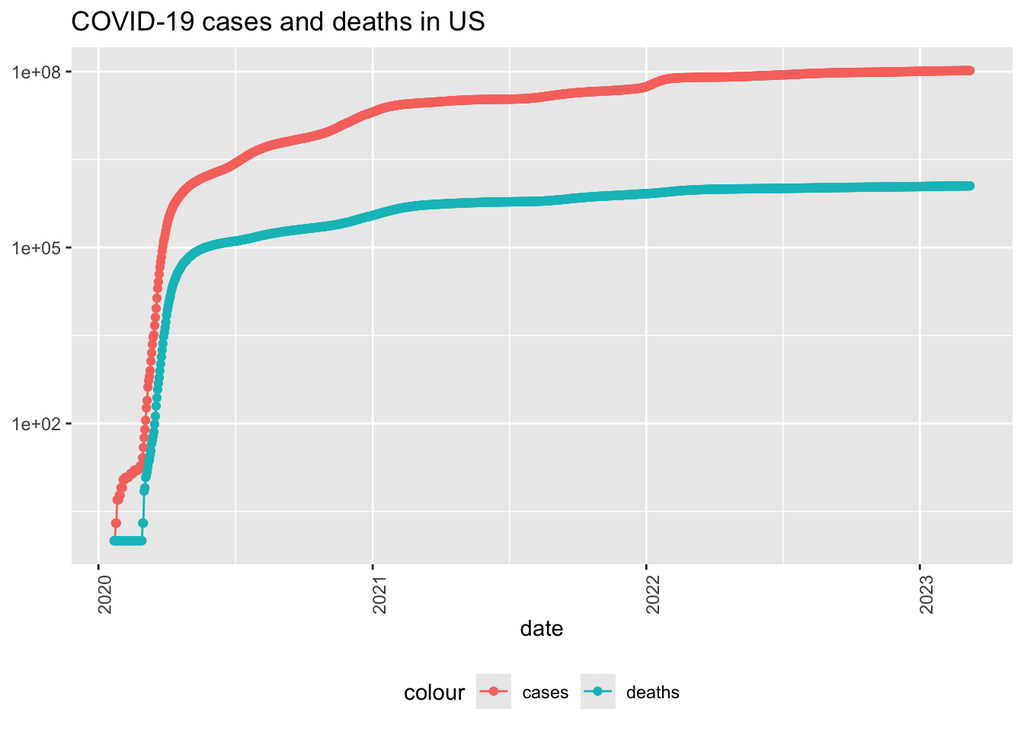

```r
#plot US data

US_totals %>%
  filter(cases >0) %>%
  ggplot(aes(x=date, y=cases)) +
  geom_line(aes(color="cases")) +
  geom_point(aes(color="cases")) +
  geom_line(aes(y=deaths, color="deaths")) +
  geom_point(aes(y=deaths, color="deaths")) +
  scale_y_log10() +
  theme(legend.position="bottom",
        axis.text.x=element_text(angle=90)) +
  labs(title = "COVID-19 cases and deaths in US", y=NULL)
```

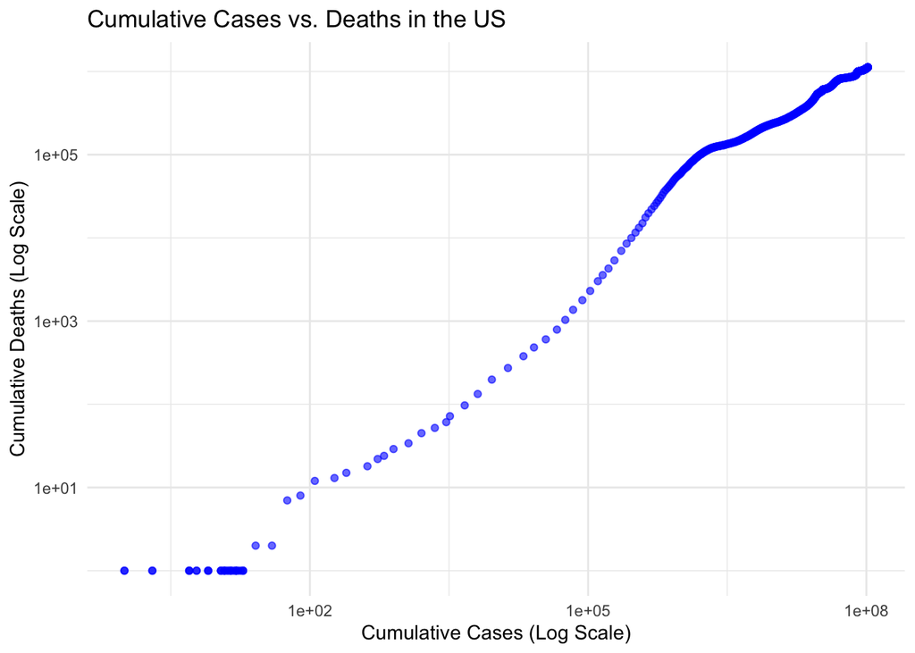

```r
#New Visualization 1: Cumulative Cases vs. Deaths (Scatter Plot with Log Scale)
# This scatter plot will show the relationship between cumulative cases and cumulative deaths in the US.
# We'll use a log scale to visualize a wide range of values effectively.

US_totals %>%
  filter(cases > 0, deaths > 0) %>%
  ggplot(aes(x = cases, y = deaths)) +
  geom_point(alpha = 0.6, color = "blue") +
  scale_x_log10() +
  scale_y_log10() +
  labs(title = "Cumulative Cases vs. Deaths in the US",
       x = "Cumulative Cases (Log Scale)",
       y = "Cumulative Deaths (Log Scale)") +
  theme_minimal()
```

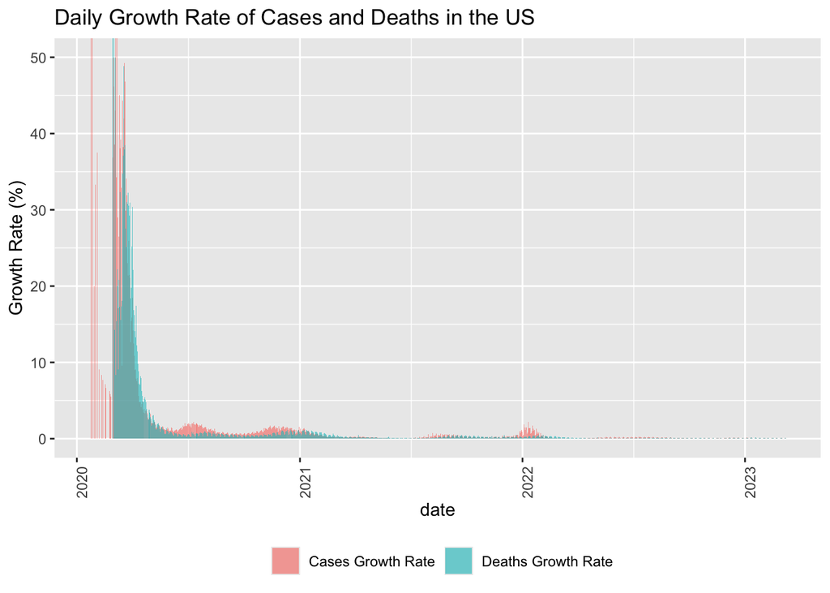

```r
#New Visualization 2: Cases and Deaths Growth Rate (Bar Chart)
#This bar chart tracks the daily percentage growth rates of both cases and deaths, helping to highlight periods of rapid growth or slowdown.
US_totals %>%
  filter(cases > 0, deaths > 0) %>%
  mutate(growth_rate_cases = (cases - lag(cases)) / lag(cases) * 100,
         growth_rate_deaths = (deaths - lag(deaths)) / lag(deaths) * 100) %>%
  replace_na(list(growth_rate_cases = 0, growth_rate_deaths = 0)) %>%
  ggplot(aes(x = date)) +
  geom_bar(aes(y = growth_rate_cases, fill = "Cases Growth Rate"), stat = "identity", alpha = 0.6) +
  geom_bar(aes(y = growth_rate_deaths, fill = "Deaths Growth Rate"), stat = "identity", alpha = 0.6) +
  coord_cartesian(ylim = c(0, 50)) +  # Adjust y-axis limits to zoom in
  labs(title = "Daily Growth Rate of Cases and Deaths in the US",
       y = "Growth Rate (%)",
       fill = "") +
  theme(axis.text.x = element_text(angle = 90),
        legend.position = "bottom")
```

In the first plot of ‘COVID-19 cases and deaths in the US’, we see that cases and deaths follow similar trends with a large increase around March/April 2020 and continue to increase but somewhat level-out through the beginning of 2023. In the new visualization, Cumulative Cases vs Deaths in the US, it shows the relationship between cumulative cases and cumulative deaths in the US which seems to be a positive linear relationship. In the second new visualization, Daily Growth Rate of Cases and Deaths in the US, this bar chart tracks the daily percentage growth rates of both cases and deaths, helping to highlight periods of rapid growth or slowdown. We see large growth rates in the beginning of 2020 and a few other spikes in the beginning of 2021 and 2022.

## Further Transformation and Analysis

```r
US_by_state <- US_by_state %>%
  mutate(new_cases = cases - lag(cases),
         new_deaths = deaths - lag(deaths))

US_totals <- US_totals %>%
  mutate(new_cases = cases - lag(cases),
         new_deaths = deaths - lag(deaths))

#transform to group by state and deaths and cases per thousand
US_state_totals <- US_by_state %>%
  group_by(Province_State) %>%
  summarize(deaths = max(deaths), cases = max(cases),
            population = max(Population),
            cases_per_thou = 1000 * cases / population,
            deaths_per_thou = 1000 * deaths / population) %>%
  filter(cases >0, population >0)

#Lets look at the 10 states that had the least amount of deaths per thousand
US_state_totals %>%
  slice_min(deaths_per_thou, n=10) %>%
  select(deaths_per_thou, cases_per_thou, everything())
```

| deaths_per_thou | cases_per_thou | Province_State | deaths | cases | population |
| --- | --- | --- | --- | --- | --- |
| 0.6110602 | 149.5300 | American Samoa | 34 | 8320 | 55641 |
| 0.7435079 | 247.8239 | Northern Mariana Islands | 41 | 13666 | 55144 |
| 1.2119178 | 231.3178 | Virgin Islands | 130 | 24813 | 107268 |
| 1.3002588 | 268.8153 | Hawaii | 1841 | 380608 | 1415872 |
| 1.4888083 | 244.5844 | Vermont | 929 | 152618 | 623989 |
| 1.5507575 | 293.3387 | Puerto Rico | 5823 | 1101469 | 3754939 |
| 1.6525482 | 340.0999 | Utah | 5298 | 1090346 | 3205958 |
| 2.0054116 | 415.1917 | Alaska | 1486 | 307655 | 740995 |
| 2.0290500 | 252.1364 | District of Columbia | 1432 | 177945 | 705749 |
| 2.0595168 | 253.3080 | Washington | 15683 | 1928913 | 7614893 |

```r
#Here are the 10 states that had the most amount of deaths per thousand
US_state_totals %>%
  slice_max(deaths_per_thou, n=10) %>%
  select(deaths_per_thou, cases_per_thou, everything())
```

| deaths_per_thou | cases_per_thou | Province_State | deaths | cases | population |
| --- | --- | --- | --- | --- | --- |
| 4.547780 | 335.7067 | Arizona | 33102 | 2443514 | 7278717 |
| 4.541858 | 326.2417 | Oklahoma | 17972 | 1290929 | 3956971 |
| 4.492383 | 332.8987 | Mississippi | 13370 | 990756 | 2976149 |
| 4.441600 | 358.6536 | West Virginia | 7960 | 642760 | 1792147 |
| 4.321287 | 319.9732 | New Mexico | 9061 | 670929 | 2096829 |
| 4.314396 | 333.6476 | Arkansas | 13020 | 1006883 | 3017804 |
| 4.289457 | 335.4010 | Alabama | 21032 | 1644533 | 4903185 |
| 4.284998 | 368.2920 | Tennessee | 29263 | 2515130 | 6829174 |
| 4.226054 | 306.8157 | Michigan | 42205 | 3064125 | 9986857 |
| 4.058041 | 384.6457 | Kentucky | 18130 | 1718471 | 4467673 |

In this analysis, we wanted to look at which states had the most and least deaths per thousand residents. The state/territory with the least amount of deaths per thousand residents was American Samoa and the state territory with the most amount of deaths per thousand residents was Arizona.

## Modeling the Data

```r
#Simple Linear Regression Model to predict deaths based on the number of cases in the US.

# Filter data to only include rows where both cases and deaths are greater than 0
US_lm_data <- US_totals %>%
  filter(cases > 0, deaths > 0)

# Fit a simple linear regression model
model <- lm(deaths ~ cases, data = US_lm_data)

# Summary of the model
summary(model)
```

```
##
## Call:
## lm(formula = deaths ~ cases, data = US_lm_data)
##
## Residuals:
##     Min      1Q  Median      3Q     Max
## -149805  -62016  -13343   89500  143891
##
## Coefficients:
##              Estimate Std. Error t value Pr(>|t|)
## (Intercept) 1.498e+05  3.869e+03   38.72   <2e-16 ***
## cases       1.008e-02  6.498e-05  155.19   <2e-16 ***
## ---
## Signif. codes:  0 '***' 0.001 '**' 0.01 '*' 0.05 '.' 0.1 ' ' 1
##
## Residual standard error: 80090 on 1141 degrees of freedom
## Multiple R-squared:  0.9548, Adjusted R-squared:  0.9547
## F-statistic: 2.408e+04 on 1 and 1141 DF,  p-value: < 2.2e-16
```

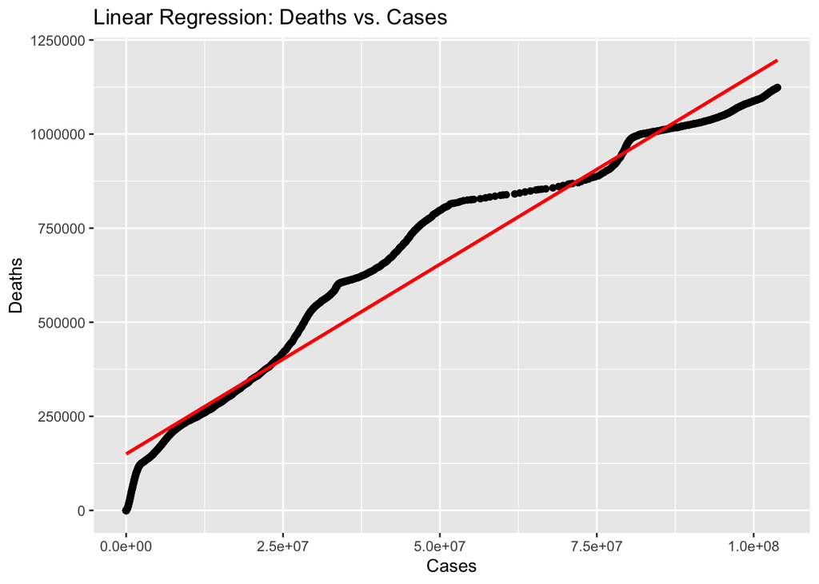

```r
# Visualize the regression model
ggplot(US_lm_data, aes(x = cases, y = deaths)) +
  geom_point() +
  geom_smooth(method = "lm", se = FALSE, color = "red") +
  labs(title = "Linear Regression: Deaths vs. Cases", x = "Cases", y = "Deaths")
```

The modeled data is a simple linear regression model to predict deaths based on the number of cases in the US. The data was filtered to only include rows where both cases and deaths are greater than 0. We see that based on the total data given between early 2020 and March 2023, the model is predicting an increase in deaths. There is a positive linear relationship between the amount of cases and deaths. We can also see from the summary output that the p-value for the predictor variable, cases, is significant (< 0.05).